# Genome-wide methylation analysis report

# Genome-wide methylation analysis report

- study: Pleural cfDNAm analysis of malig_non_infection.platevariable
- author: Paul Yousefi
- date: 08 October, 2026

## Parameters

```
## $sig.threshold
## [1] 2.121143e-07
##
## $max.plots
## [1] 10
##
## $qq.inflation.method
## [1] "median"
##
## $practical.threshold
## [1] 8.315221e-05
```

## Sample characteristics

For continuous or ordinal variables, the “mean” column provides the mean and the “sd/%” column the standard deviation of the variable. For categorical variables, the “mean” column provides the number of samples with the given “value” and the “sd/%” column the percentage of samples with the given “value”.

| variable | value | mean | sd.. |
| --- | --- | --- | --- |
| malig_non_infection |  | 0.6273063 | 0.4844162 |
| plate |  | 2.284133 | 1.052549 |
| sv1 |  | -3.077011e-19 | 0.06085806 |
| sv2 |  | 4.002246e-19 | 0.06085806 |
| sv3 |  | 2.044131e-18 | 0.06085806 |
| sv4 |  | 1.85207e-18 | 0.06085806 |
| sv5 |  | 7.220559e-18 | 0.06085806 |
| sv6 |  | 2.744312e-18 | 0.06085806 |
| sv7 |  | -7.820858e-18 | 0.06085806 |
| sv8 |  | -3.08997e-18 | 0.06085806 |
| sv9 |  | 3.32998e-18 | 0.06085806 |
| sv10 |  | 2.913562e-16 | 0.06085806 |

## Covariate associations

### Covariate plate

statistics

| var1 | var2 | F | p-value | R | p-value |
| --- | --- | --- | --- | --- | --- |
| malig_non_infection | plate | 1.82556 | 0.1777882 | -0.0819137 | 0.1787879 |

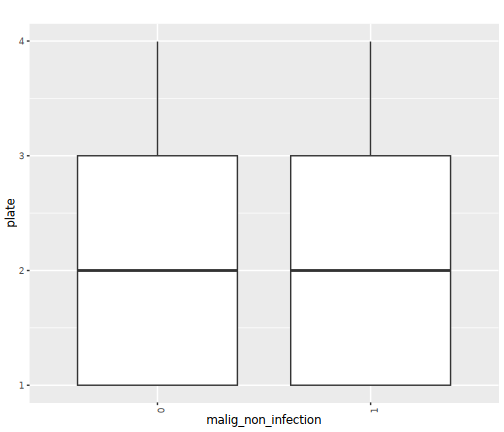

### Covariate sv1

statistics

| var1 | var2 | F | p-value | R | p-value |
| --- | --- | --- | --- | --- | --- |
| malig_non_infection | sv1 | 4.860282 | 0.0283285 | 0.1378419 | 0.0232367 |

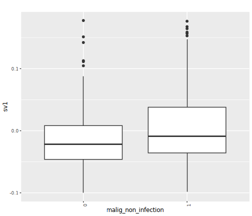

### Covariate sv2

statistics

| var1 | var2 | F | p-value | R | p-value |
| --- | --- | --- | --- | --- | --- |
| malig_non_infection | sv2 | 1.090059 | 0.2973953 | -0.0847733 | 0.1640437 |

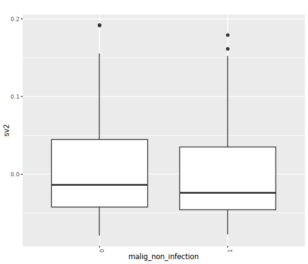

### Covariate sv3

statistics

| var1 | var2 | F | p-value | R | p-value |
| --- | --- | --- | --- | --- | --- |
| malig_non_infection | sv3 | 0.1168676 | 0.7327239 | -0.028778 | 0.6371737 |

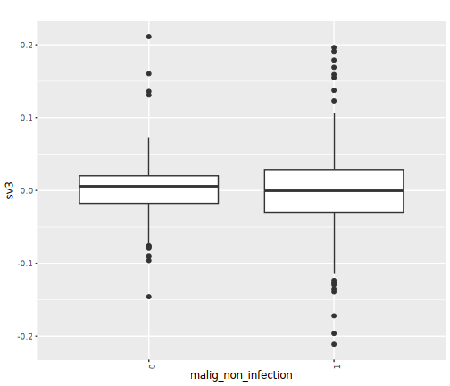

### Covariate sv4

statistics

| var1 | var2 | F | p-value | R | p-value |
| --- | --- | --- | --- | --- | --- |
| malig_non_infection | sv4 | 0.0148739 | 0.9030227 | 0.0078042 | 0.8982426 |

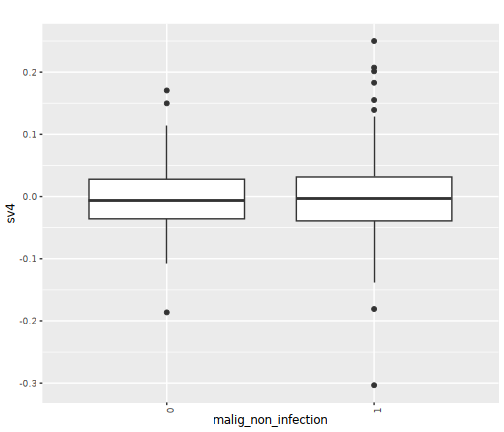

### Covariate sv5

statistics

| var1 | var2 | F | p-value | R | p-value |
| --- | --- | --- | --- | --- | --- |
| malig_non_infection | sv5 | 0.0707011 | 0.7905224 | -0.031412 | 0.6066628 |

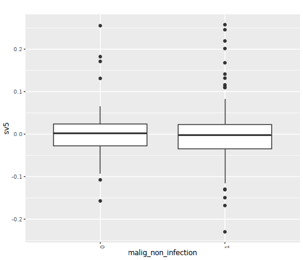

### Covariate sv6

statistics

| var1 | var2 | F | p-value | R | p-value |
| --- | --- | --- | --- | --- | --- |
| malig_non_infection | sv6 | 0.0008483 | 0.9767862 | 0.0143402 | 0.8142157 |

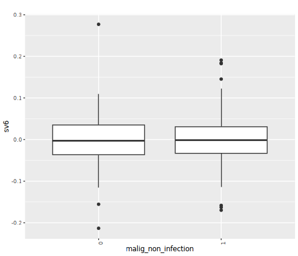

### Covariate sv7

statistics

| var1 | var2 | F | p-value | R | p-value |
| --- | --- | --- | --- | --- | --- |
| malig_non_infection | sv7 | 0.3982382 | 0.5285363 | 0.0135598 | 0.8241572 |

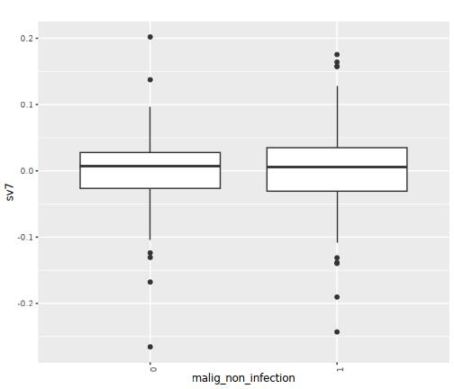

### Covariate sv8

statistics

| var1 | var2 | F | p-value | R | p-value |
| --- | --- | --- | --- | --- | --- |
| malig_non_infection | sv8 | 1.422702 | 0.2340101 | -0.0538491 | 0.3772304 |

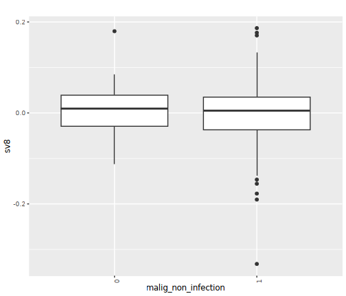

### Covariate sv9

statistics

| var1 | var2 | F | p-value | R | p-value |
| --- | --- | --- | --- | --- | --- |
| malig_non_infection | sv9 | 0.1793696 | 0.672254 | -0.0261441 | 0.6683088 |

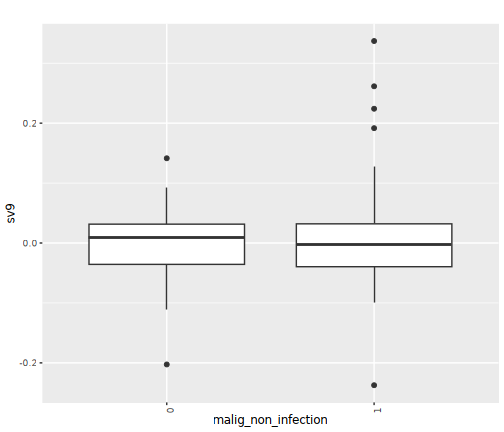

### Covariate sv10

statistics

| var1 | var2 | F | p-value | R | p-value |
| --- | --- | --- | --- | --- | --- |
| malig_non_infection | sv10 | 0.2718695 | 0.6025094 | -0.0084871 | 0.8893935 |

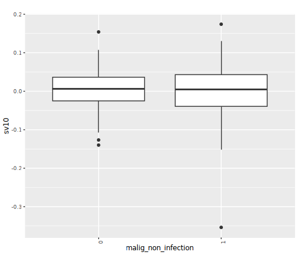

## QQ plots

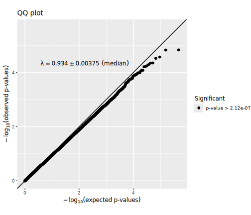

## Manhattan plots

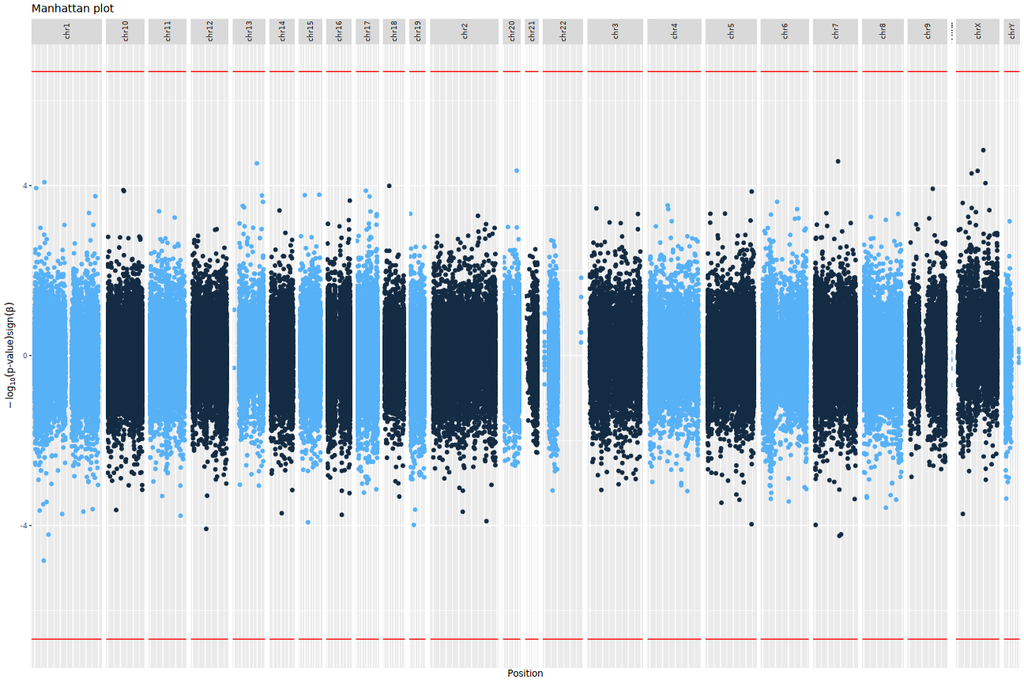

## Significant CpG sites

There were 0 CpG sites with association p-values < 2.1211427 × 10<sup>-7</sup>. These are listed in the file associations.csv.

Below are the 10 CpG sites with association p-values < 8.3152211 × 10<sup>-5</sup> in the regression model.

|  | chromosome | position | estimate | p.value | p.adjust |
| --- | --- | --- | --- | --- | --- |
| cg09790289 | chrX | 77359560 | 0.0449791 | 4.52e-05 | 1 |
| cg06070414 | chr7 | 95226412 | -0.0572461 | 5.70e-05 | 1 |
| cg27358021 | chrX | 99661597 | 0.0707447 | 1.47e-05 | 1 |
| cg14424181 | chr20 | 51400526 | 0.0794248 | 4.46e-05 | 1 |
| cg18973058 | chr13 | 88900824 | 0.0225286 | 3.01e-05 | 1 |
| cg13409996 | chr1 | 35544630 | -0.0261565 | 1.49e-05 | 1 |
| cg27067307 | chrX | 53710733 | 0.0297416 | 5.19e-05 | 1 |
| cg00784644 | chr1 | 54203161 | -0.0727330 | 6.12e-05 | 1 |
| cg17696409 | chr7 | 102053153 | -0.0611820 | 6.18e-05 | 1 |
| cg04549111 | chr7 | 90138040 | 0.0365864 | 2.70e-05 | 1 |

Plots of these sites follow, one for each covariate set. “p[lm]” denotes the p-value obtained using a linear model and “p[beta]” the p-value obtained using beta regression.

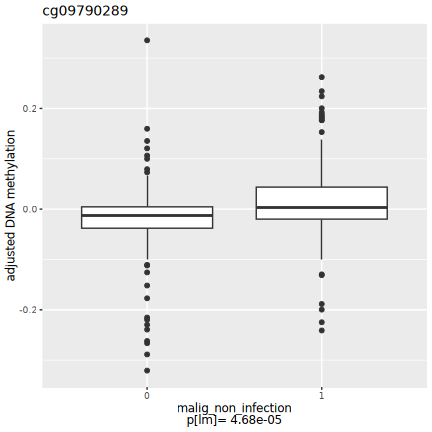

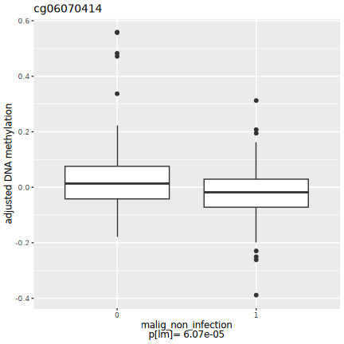

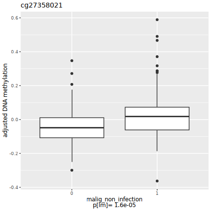

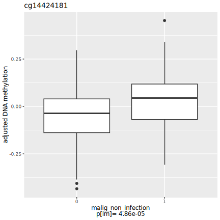

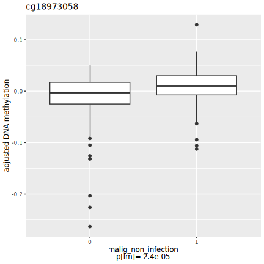

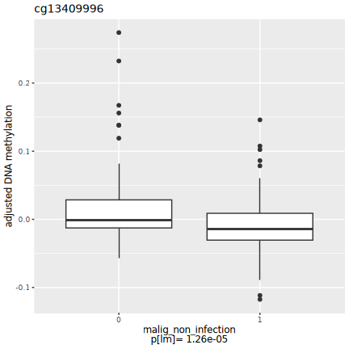

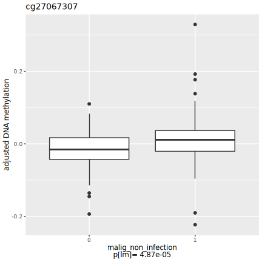

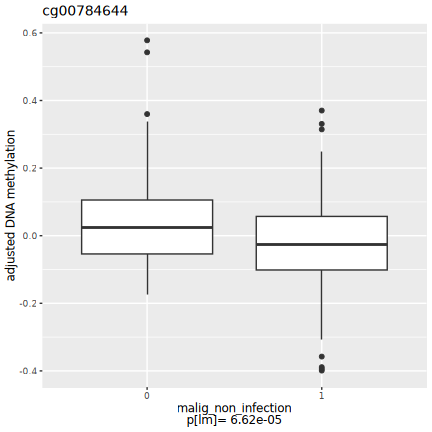

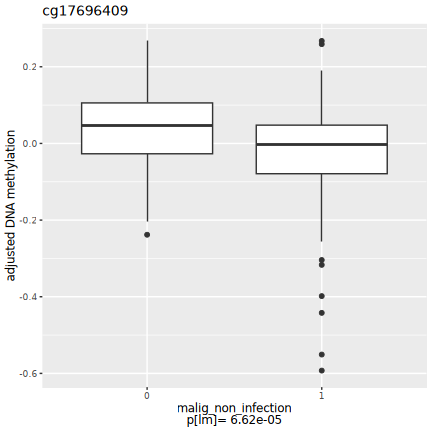

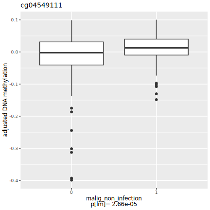

## Selected CpG sites

Number of CpG sites selected: 0.

| chromosome | position | estimate | p.value | p.adjust |
| --- | --- | --- | --- | --- |